# Firm exit prediction - Data cleaning

Viktória Kónya

17 February, 2022

```r
# Clear environment
rm(list=ls())

# Folder locations
main <- getwd()
data_raw <- paste0(main, '/data/raw')
data_work <- paste0(main, '/data/work')
output <- paste0(main, '/output')

# Import libraries
library(tidyverse)
library(modelsummary)
library(Hmisc)
library(kableExtra)
library(gridExtra)
```

### Dataset

Import the data and check the variables.

```r
# Import cleaned dataset
data <- read_csv("https://osf.io/3qyut/download")
```

```r
# Check summary statistics
datasummary_skim(data, 'numeric')
```

Unique (#)

Missing (%)

Mean

SD

Min

Median

Max

comp_id

46412

0

154086230015.6

138242419520.0

1001034.0

115285049344.0

464120938496.0

[figure not shown]

COGS

9791

94

460168.3

2614148.7

-844570.4

7040.7

94996928.0

[figure not shown]

amort

21503

3

23532.6

821666.8

-307670.4

781.5

182088896.0

[figure not shown]

curr_assets

57157

0

220939.5

4182019.9

-555555.6

9592.6

1299011072.0

[figure not shown]

curr_liab

57107

0

174249.9

3730357.2

-772711.1

10492.6

1683374080.0

[figure not shown]

extra_exp

4256

6

1521.7

72373.4

-490270.3

0.0

17041718.0

[figure not shown]

extra_inc

8176

6

3754.5

172779.4

-274407.4

0.0

72330776.0

[figure not shown]

extra_profit_loss

11098

6

2229.1

161116.9

-6181263.0

0.0

72330776.0

[figure not shown]

finished_prod

4207

94

105648.1

533805.3

0.0

0.0

18036354.0

[figure not shown]

fixed_assets

60192

0

339373.1

18231763.2

-2394226.0

3825.9

7940211200.0

[figure not shown]

inc_bef_tax

45020

3

23324.2

2413798.7

-335514816.0

70.4

897699968.0

[figure not shown]

intang_assets

9941

0

37824.2

6260181.1

-3770.4

0.0

1813455616.0

[figure not shown]

inventories

28295

0

60527.3

667005.4

-30696.3

455.6

107853264.0

[figure not shown]

liq_assets

32095

0

40987.2

660256.4

-555555.6

1851.9

161754672.0

[figure not shown]

material_exp

77353

3

359464.8

2940907.2

-12399737.0

23614.8

152163072.0

[figure not shown]

net_dom_sales

15052

94

2118066.0

6746671.5

-845848.1

194337.3

108910088.0

[figure not shown]

net_exp_sales

7085

94

3368463.0

11352023.5

-14700067.0

0.0

110534024.0

[figure not shown]

personnel_exp

45299

3

92294.0

705833.7

-433807.4

7885.2

61469132.0

[figure not shown]

profit_loss_year

37936

3

5152.3

1892475.4

-335514816.0

0.0

897699968.0

[figure not shown]

sales

88515

3

504251.3

3861889.6

-14725589.0

32807.4

111029448.0

[figure not shown]

share_eq

78801

0

235056.4

7465365.9

-42104452.0

3838.9

2795907328.0

[figure not shown]

subscribed_cap

3746

0

77414.4

1746094.8

-555555.6

5555.6

691800000.0

[figure not shown]

tang_assets

58519

1

221627.3

2580850.8

-2390455.5

3311.1

451100736.0

[figure not shown]

wages

13011

94

655471.4

1725947.4

-1825248.1

64855.6

45534984.0

balsheet_flag

2

0

0.0

0.1

0.0

0.0

1.0

[figure not shown]

balsheet_length

366

0

345.6

65.5

0.0

364.0

365.0

[figure not shown]

balsheet_notfullyear

2

0

0.1

0.3

0.0

0.0

1.0

[figure not shown]

year

12

0

2010.6

3.2

2005.0

2011.0

2016.0

[figure not shown]

founded_year

39

20

2002.2

6.9

1950.0

2002.0

2015.0

exit_year

19

86

2014.0

2.2

1997.0

2015.0

2017.0

[figure not shown]

ceo_count

15

20

1.3

0.5

1.0

1.0

15.0

[figure not shown]

foreign

16

20

0.1

0.3

0.0

0.0

1.0

[figure not shown]

female

15

20

0.3

0.4

0.0

0.0

1.0

[figure not shown]

birth_year

265

39

1964.9

11.5

1920.0

1966.0

2016.0

[figure not shown]

inoffice_days

11180

20

3205.3

1880.6

1.0

2838.0

10983.0

[figure not shown]

nace_main

301

0

4858.2

1250.0

111.0

5610.0

9609.0

[figure not shown]

ind2

69

0

48.4

12.6

1.0

56.0

96.0

[figure not shown]

ind

4

3

2.7

0.5

1.0

3.0

3.0

[figure not shown]

urban_m

3

0

2.1

0.8

1.0

2.0

3.0

[figure not shown]

labor_avg

5824

51

1.0

4.8

0.0

0.2

219.3

[figure not shown]

There are 46412 individual firms in the dataset for 2005-2016 period. For the further analysis, I will restrict the dataset for the 2011-2014 periods (one lagging, 2 leading periods are needed for the 2012 cross-section).

The following fields have high missing rates (above 90%) : COGS, finished_prod, net_dom_sales, net_exp_sales. I will drop these variables from the dataset.

```r
# Keep only 2011-2014
data <- data %>%
  filter((year >= 2011) & (year <= 2014) & (balsheet_length >= 360))

# Drop variables with many NAs
data <- data %>%
  select(-c(COGS, finished_prod, net_dom_sales, net_exp_sales, wages))
```

### Label engineering

The target variable the growth rate over two years which was defined using the Compound Annual Growth Rate (CAGR) formula:

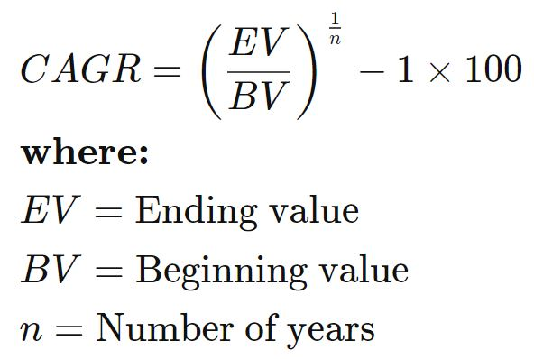

- The sales revenue was converted to million EUR first and
- For new firms (age <= 1 or no full year balance sheet available) and for firms that left the market the growth rate was modified to zero.

```r
# Create all year - comp_id combination (NAs will be added to missing combinations)
#data <- data %>%
 # complete(year, comp_id)

# Generate status_alive; if sales larger than zero and not-NA, then firm is alive
data  <- data %>%
  mutate(status_alive = sales > 0 & !is.na(sales) %>%
           as.numeric(.))

# Create growth variables - Floor sales to 1, rescale and create logs
data <- data %>%
  mutate(sales = ifelse(sales < 0, 1, sales), # Floor sales to 1
         sales_lag1 = Lag(sales),
         ln_sales = ifelse(sales > 0, log(sales), 0),
         sales_mil=sales/1000000, # Create sales in million
         sales_mil_log = ifelse(sales > 0, log(sales_mil), 0)) # Create log of million sales

# Create square of sales mil
data <- data %>%
  mutate(sales_mil_log_sq=sales_mil_log^2)

# Create first difference
data <- data %>%
  group_by(comp_id) %>%
  mutate(d1_sales_mil_log = sales_mil_log - Lag(sales_mil_log, 1)) %>%
  ungroup()

# Add 0 sales change for new firms (age <= 1 or no balance sheet available for the year)
data <- data %>%
  mutate(age = (year - founded_year) %>%
           ifelse(. < 0, 0, .),
         new = as.numeric(age <= 1) %>% #  (age could be 0,1 )
           ifelse(balsheet_notfullyear == 1, 1, .),
         d1_sales_mil_log = ifelse(new == 1, 0, d1_sales_mil_log),
         new = ifelse(is.na(d1_sales_mil_log) , 1, new), # if no data is available for the last year then the company is new
         d1_sales_mil_log = ifelse(is.na(d1_sales_mil_log), 0, d1_sales_mil_log)
         )

# Winsorize the tails [-1.5, 1.5]
data <- data %>%
  mutate(flag_low_d1_sales_mil_log = ifelse(d1_sales_mil_log < -1.5, 1, 0),
         flag_high_d1_sales_mil_log = ifelse(d1_sales_mil_log > 1.5, 1, 0),
         d1_sales_mil_log_mod = ifelse(d1_sales_mil_log < -1.5, -1.5,
                                       ifelse(d1_sales_mil_log > 1.5, 1.5, d1_sales_mil_log)),
         d1_sales_mil_log_mod_sq = d1_sales_mil_log_mod^2)


data <- data %>%
  group_by(comp_id) %>%
  mutate(sales_growth_2 = ((lead(sales_mil, 2) / sales_mil)^(1/2)-1 ) * 100) %>%
  ungroup()

# Example
data_ch <- data %>% filter(comp_id == '1001541') %>%  select(comp_id, year, sales, sales_mil, sales_growth_2) %>% arrange(comp_id)

kable(data_ch) %>%
  kable_styling(font_size = 11, full_width = F) %>%
  scroll_box(width = "900px")
```

| comp_id | year | sales | sales_mil | sales_growth_2 |
| --- | --- | --- | --- | --- |
| 1001541 | 2011 | 0.000 | 0.0000000 | Inf |
| 1001541 | 2012 | 1203.704 | 0.0012037 | 101.5326 |
| 1001541 | 2013 | 5555.556 | 0.0055556 | NA |
| 1001541 | 2014 | 4888.889 | 0.0048889 | NA |

### Sample design

2012 cross section was selected for the sample.

- Only kept alive firms (with sales > 0)
- Filtered out firms with very low (below 1000 EUR) and very high (above 10M EUR) sales.
- Firms that did not have 4 years available (2011-2014) data were excluded.
- Filtered out firms with missing growth rate.
- The sample consists of 13.339 firms

```r
# 2012 cross section and filter for alive firms and firms below 10m euro revenues and above 1000 euros
data <- data %>%
  filter(status_alive == 1) %>%
  filter(!(sales_mil > 10)) %>%
  filter(!(sales_mil < 0.001))

# Keep only firms with complete 4 yers data
complete_filter <- data %>% group_by(comp_id) %>% dplyr::summarize(count_per = n()) %>% filter(count_per == 4)
data <- data %>% filter(comp_id %in% complete_filter$comp_id)

# Keep with available growth rate and 2012 cross-section
data <- data %>%
          filter(!is.na(sales_growth_2)) %>%
          filter(year == 2012)
```

Let’s check the growth rate.

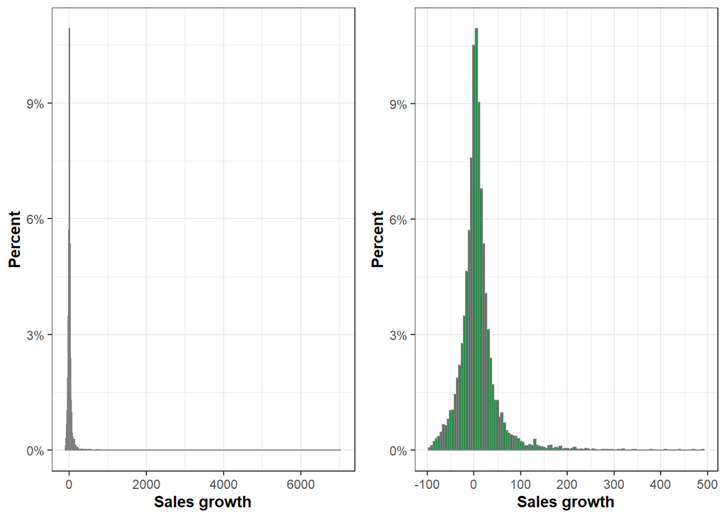

```r
# Histogram of sales growth
p1 <- ggplot( data  , aes(x = sales_growth_2)) +
    geom_histogram( aes(y = (..count..)/sum(..count..)), binwidth = 5, fill="#238b45", color = 'gray50', na.rm = T) +
    labs(y = 'Percent',x = "Sales growth" ) +
    scale_y_continuous(labels = scales::percent_format(1)) +
    theme_bw() +
    theme(
      plot.title = element_text(size = 12L,
                                face = "bold", hjust = 0.5),
      axis.title.y = element_text(face = "bold"),
      axis.title.x = element_text(face = "bold"),
      legend.position = "none")

p2 <- ggplot( data %>% filter(sales_growth_2 < 500)  , aes(x = sales_growth_2)) +
    geom_histogram( aes(y = (..count..)/sum(..count..)), binwidth = 5, fill="#238b45", color = 'gray50', na.rm = T) +
    labs(y = 'Percent',x = "Sales growth" ) +
    scale_y_continuous(labels = scales::percent_format(1)) +
    theme_bw() +
    theme(
      plot.title = element_text(size = 12L,
                                face = "bold", hjust = 0.5),
      axis.title.y = element_text(face = "bold"),
      axis.title.x = element_text(face = "bold"),
      legend.position = "none")

grid.arrange(p1, p2, nrow = 1)
```

The distribution of the growth rates are centered close to zero with a long right tail. There are 7 firms with extreme high growth rate above 1000%.

```r
kable(data %>% filter(sales_growth_2 > 1000)) %>%
  kable_styling(font_size = 11, full_width = F) %>%
  scroll_box(width = "900px")
```

| comp_id | begin | end | amort | curr_assets | curr_liab | extra_exp | extra_inc | extra_profit_loss | fixed_assets | inc_bef_tax | intang_assets | inventories | liq_assets | material_exp | personnel_exp | profit_loss_year | sales | share_eq | subscribed_cap | tang_assets | D | balsheet_flag | balsheet_length | balsheet_notfullyear | year | founded_year | exit_year | ceo_count | foreign | … |
| --- | --- | --- | --- | --- | --- | --- | --- | --- | --- | --- | --- | --- | --- | --- | --- | --- | --- | --- | --- | --- | --- | --- | --- | --- | --- | --- | --- | --- | --- | --- |
| 4818832896 | 2012-01-01 | 2012-12-31 | 385.18518 | 19333.3340 | 18374.0742 | 0 | 0.00000 | 0.00000 | 970.3704 | -885.1852 | 0.00 | 0.0000 | 17092.5918 | 411.1111 | 0.000 | -888.8889 | 1051.852 | 1929.6296 | 1851.85181 | 970.3704 | NA | 0 | 365 | 0 | 2012 | 2009 | NA | 1 | 0 | … |
| 29510526976 | 2012-01-01 | 2012-12-31 | 0.00000 | 1174.0741 | 6688.8887 | 0 | 18.51852 | 18.51852 | 0.0000 | -6537.0371 | 0.00 | 0.0000 | 1162.9630 | 8381.4814 | 1003.704 | -6540.7407 | 2837.037 | -15070.3701 | 1888.88892 | 0.0000 | NA | 0 | 365 | 0 | 2012 | 2010 | NA | 2 | 0 | … |
| 35949682688 | 2012-01-01 | 2012-12-31 | 529.62964 | 1196.2963 | 659.2593 | 0 | 0.00000 | 0.00000 | 1177.7778 | 1718.5186 | 0.00 | 0.0000 | 1155.5555 | 848.1481 | 0.000 | 1551.8518 | 3096.296 | 233.3333 | 1851.85181 | 1177.7778 | NA | 0 | 365 | 0 | 2012 | 2010 | NA | 1 | 0 | … |
| 140102582272 | 2012-01-01 | 2012-12-31 | 22.22222 | 248.1481 | 9892.5928 | 0 | 0.00000 | 0.00000 | 30992.5918 | 1788.8889 | 0.00 | 0.0000 | 248.1481 | 196.2963 | 0.000 | 1707.4073 | 2222.222 | 21488.8887 | 37.03704 | 30992.5918 | NA | 0 | 365 | 0 | 2012 | 2004 | NA | 2 | 0 | … |
| 233602023424 | 2012-01-01 | 2012-12-31 | 0.00000 | 171996.2969 | 214577.7812 | 0 | 0.00000 | 0.00000 | 87777.7812 | 3911.1111 | 87777.78 | 0.0000 | 3144.4443 | 7337.0371 | 0.000 | 3492.5925 | 11851.852 | 62655.5547 | 18518.51758 | 0.0000 | NA | 0 | 365 | 0 | 2012 | 2009 | NA | 1 | 1 | … |
| 320040566784 | 2012-01-01 | 2012-12-31 | 418.51852 | 10725.9258 | 137744.4375 | 0 | 0.00000 | 0.00000 | 157677.7812 | -11255.5557 | 0.00 | 488.8889 | 10237.0371 | 1996.2963 | 5800.000 | -11262.9629 | 1481.481 | -5711.1113 | 9259.25879 | 157677.7812 | NA | 0 | 365 | 0 | 2012 | 2010 | NA | 1 | 0 | … |
| 389610897408 | 2012-01-01 | 2012-12-31 | 4444.44434 | 10237.0371 | 9037.0371 | 0 | 0.00000 | 0.00000 | 14055.5557 | -5625.9258 | 0.00 | 0.0000 | 10225.9258 | 755.5555 | 0.000 | -5629.6294 | 1000.000 | 9651.8516 | 11111.11133 | 14055.5557 | NA | 0 | 365 | 0 | 2012 | 2004 | NA | 1 | 1 | … |

For the analysis I will exclude firms with growth rate above 2000% as such record high growth rate is unlikely among SMEs.

```r
data <- data %>% filter(sales_growth_2 < 2000)
```

In order to decide about the cutoff value for fast growing, let’s check the summary statistics of the growth rate.

```r
# Summary
P60 <- function(x){quantile(x,0.60,na.rm=T)}
P65 <- function(x){quantile(x,0.65,na.rm=T)}
P70 <- function(x){quantile(x,0.70,na.rm=T)}
P75 <- function(x){quantile(x,0.75,na.rm=T)}
P80 <- function(x){quantile(x,0.80,na.rm=T)}
P85 <- function(x){quantile(x,0.85,na.rm=T)}
P90 <- function(x){quantile(x,0.90,na.rm=T)}
P95 <- function(x){quantile(x,0.95,na.rm=T)}
P05 <- function(x){quantile(x,0.05,na.rm=T)}
# Range <- function(x){max(x, na.rm = TRUE) - min(x, na.rm = TRUE)}
Missing <- function(x){sum(is.na(x))}
Mean2 <- function(x){mean(x,na.rm=T)}

datasummary(  (sales_growth_2)  ~
    (N + Missing + Mean2 + SD + Min + Max + P05 + Median  + P60 + P65 + P70 + P75 + P80 + P85 + P90 + P95),
    data = data,
    title = 'Descriptive statistics of growth rate' ) %>%
    kableExtra::kable_styling(latex_options = "hold_position", font_size = 10)
```

Descriptive statistics of growth rate

|  | N | Missing | Mean2 | SD | Min | Max | P05 | Median | P60 | P65 | P70 | P75 | P80 | P85 | P90 | P95 |
| --- | --- | --- | --- | --- | --- | --- | --- | --- | --- | --- | --- | --- | --- | --- | --- | --- |
| sales_growth_2 | 13336 | 0.00 | 10.81 | 59.34 | -95.76 | 1965.31 | -45.64 | 4.33 | 9.23 | 12.01 | 15.47 | 19.72 | 25.11 | 32.40 | 45.70 | 75.06 |

```r
# Add fast growing flag as growth rate > 30%
data <- data %>% mutate(fast_growing_flg = ifelse(sales_growth_2 > 30, 1, 0))

# Create factor
data <- data %>%
  mutate(fast_growing_f = factor(fast_growing_flg, levels = c(0,1)) %>%
           recode(., `0` = 'not_fast_growing', `1` = "fast_growing"))
```

Let’s check the number of firms by the fast growing flag.

```r
kable(data %>% group_by(fast_growing_flg) %>%  dplyr::summarize(count = n())) %>%
  kable_styling(font_size = 11, full_width = F) %>%
  scroll_box(width = "900px")
```

| fast_growing_flg | count |
| --- | --- |
| 0 | 11129 |
| 1 | 2207 |

We have 11.129 observations in the baseline and 2207 obseravtions in the fast growing group.

### Feature engineering - Industry andrelated variables

Industry related variables were created:

- ind2_cat: Industry categories were grouped and converted to factor
- age and age squared
- factors were created from the characters: gender_m, m_region_loc, urban_m

```r
# Industry category codes grouped
data <- data %>%
  mutate(ind2_cat = ind2 %>%
           ifelse(. > 56, 60, .)  %>%
           ifelse(. < 26, 20, .) %>%
           ifelse(. < 55 & . > 35, 40, .) %>%
           ifelse(. == 31, 30, .) %>%
           ifelse(is.na(.), 99, .)
           )

# Other industry variables: age, foreign, gender, region
data <- data %>%
  mutate(age2 = age^2,
         gender_m = factor(gender, levels = c("female", "male", "mix")),
         m_region_loc = factor(region_m, levels = c("Central", "East", "West")))

# Create factors for urban, industry
data <- data %>%
  mutate(urban_m = factor(urban_m, levels = c(1,2,3)),
         ind2_cat = factor(ind2_cat, levels = sort(unique(data$ind2_cat))))
```

### Feature engineering - Financial variables

Financial variables were corrected and transformed:

- Asset side variables (intang_assets, curr_assets, fixed_assets) with negative values were floored at 0 as they cannot be negative.
- flag_asset_problem: Flag for assets with negative value was added to measure the quality of the financial variables.
- total_assets_bs: Total assets were calculated from the asset side items.
- Ratios were created from the asset side items by dividing them by the total asset (suffixed with ‘bs_’)
- Ratios were created from the P&L items by dividing them by the sales value (suffixed with ‘pl_’)

```r
# Assets can't be negative. Floor them to 0 and add a flag
data <-data  %>%
  mutate(flag_asset_problem=ifelse(intang_assets<0 | curr_assets<0 | fixed_assets<0,1,0  ))

data <- data %>%
  mutate(intang_assets = ifelse(intang_assets < 0, 0, intang_assets),
         curr_assets = ifelse(curr_assets < 0, 0, curr_assets),
         fixed_assets = ifelse(fixed_assets < 0, 0, fixed_assets))

# Generate total assets
data <- data %>%
  mutate(total_assets_bs = intang_assets + curr_assets + fixed_assets)

# Create ratios of financial variables
#   - Divide P&L items by sales
#   - Divide asset items by total assets

pl_names <- c("extra_exp","extra_inc",  "extra_profit_loss", "inc_bef_tax" ,"inventories",
              "material_exp", "profit_loss_year", "personnel_exp")
bs_names <- c("intang_assets", "curr_liab", "fixed_assets", "liq_assets", "curr_assets",
              "share_eq", "subscribed_cap", "tang_assets" )

# P&L items; add names_pl elements to new column name
data <- data %>%
  mutate_at(vars(pl_names), funs("pl"=./sales))

# BS items; add names_bs elements to new column name
data <- data %>%
  mutate_at(vars(bs_names), funs("bs"=ifelse(total_assets_bs == 0, 0, ./total_assets_bs)))
```

### Feature engineering - Financial variables - Winsorize and create flags

- Financial ratios calculated from financial items that cannot be negative were winsorized to have values between [0, 1]
  - Flag values were added to track data issues:
    - ‘flag_high’ suffix was added to capture ratios above 1
    - ‘flag_error’ suffix was added to capture ratios with negative values
- Financial ratios calculated from financial items that can be negative were winsorized to have values between [-1, 1]
  - Flag values were added to track data issues:
    - ‘flag_high’ suffix was added to capture ratios above 1
    - ‘flag_low’ suffix was added to capture ratios below -1
    - ‘flag_zero’ suffix was added to capture ratios with 0 values
  - Quadratics were added suffixed with ‘quad’

```r
# Variables that represent accounting items that cannot be negative (add 0 for negatives, add 1 for above 1)
zero <-  c("extra_exp_pl", "extra_inc_pl", "inventories_pl", "material_exp_pl", "personnel_exp_pl",
           "curr_liab_bs", "fixed_assets_bs", "liq_assets_bs", "curr_assets_bs", "subscribed_cap_bs",
           "intang_assets_bs")

data <- data %>%
  mutate_at(vars(zero), funs("flag_high"= as.numeric(.> 1))) %>%
  mutate_at(vars(zero), funs(ifelse(.> 1, 1, .))) %>%
  mutate_at(vars(zero), funs("flag_error"= as.numeric(.< 0))) %>%
  mutate_at(vars(zero), funs(ifelse(.< 0, 0, .)))

# For vars that could be any, but are mostly between -1 and 1 (add -1 for below -1, add 1 for above 1)
any <-  c("extra_profit_loss_pl", "inc_bef_tax_pl", "profit_loss_year_pl", "share_eq_bs")

data <- data %>%
  mutate_at(vars(any), funs("flag_low"= as.numeric(.< -1))) %>%
  mutate_at(vars(any), funs(ifelse(.< -1, -1, .))) %>%
  mutate_at(vars(any), funs("flag_high"= as.numeric(.> 1))) %>%
  mutate_at(vars(any), funs(ifelse(.> 1, 1, .))) %>%
  mutate_at(vars(any), funs("flag_zero"= as.numeric(.== 0))) %>%
  mutate_at(vars(any), funs("quad"= .^2))

# Drop flags with no variation
variances <- data %>%
  select(contains("flag")) %>%
  apply(2, var, na.rm = TRUE) == 0

data <- data %>%
  select(-one_of(names(variances)[variances]))
```

### Feature engineering - HR variables (imputation was needed)

HR variables were created and imputed:

- ceo_age: Age of CEO was calculated, missings were replaced by the mean and was winsorized to have values between [25, 75].
  - Flags were added to capture field qulity:
    - flag_low_ceo_age: flag was added if the age was below 25 years
    - flag_high_ceo_age: flag was added if the age was above 75 years
    - flag_miss_ceo_age: flag was added if the age was imputed
- ceo_young: Dummy was created to capture if the CEO is below 40 years old.
- labor_avg_mod: number of employees were imputed with the mean.
- foreign_management: firms where the foreign CEO rate was above 50% was flagged as foreign.

```r
# CEO age - Replace missings with mean, floor to 25, add ceilign to 75
data <- data %>%
  mutate(ceo_age = year-birth_year,
         flag_low_ceo_age = as.numeric(ceo_age < 25 & !is.na(ceo_age)),
         flag_high_ceo_age = as.numeric(ceo_age > 75 & !is.na(ceo_age)),
         flag_miss_ceo_age = as.numeric(is.na(ceo_age)))

data <- data %>%
  mutate(ceo_age = ifelse(ceo_age < 25, 25, ceo_age) %>%
           ifelse(. > 75, 75, .) %>%
           ifelse(is.na(.), mean(., na.rm = TRUE), .),
         ceo_young = as.numeric(ceo_age < 40))

# Number of employees (very noisy measure) - Replace missings with mean
data <- data %>%
  mutate(labor_avg_mod = ifelse(is.na(labor_avg), mean(labor_avg, na.rm = TRUE), labor_avg),
         flag_miss_labor_avg = as.numeric(is.na(labor_avg)))

# Foreign management
data <- data %>% mutate(foreign_management = as.numeric(foreign >= 0.5))
```

### Additional filters and drop unused fields

- Unused factor levels were dropped
- Firms with missing key variables were dropped from the dataset instead of imputing them.
- Unused fields were removed from the dataset

```r
# Drop unused factor levels
data <- data %>%
  mutate_at(vars(colnames(data)[sapply(data, is.factor)]), funs(fct_drop))

# Drop obs if key vars missing
data <- data %>%
  filter(!is.na(liq_assets_bs),!is.na(foreign), !is.na(ind), !is.na(age), !is.na(material_exp_pl), !is.na(m_region_loc))

# Unused fields
drops <- c("D",
            "founded_year",
            "exit_year",
            "foreign",
            "birth_year",
            "inoffice_days",
            "gender",
            "origin",
            "nace_main",
            "ind",
            "region_m",
            "founded_date",
            "exit_date",
            "status_alive",
            "ind2",
            "begin",
            "end",
            "amort",
           "labor_avg"
           )

data <- data %>% select(-drops)

# Save dataset
saveRDS(data, paste0(data_work, "/bisnode_firms_cleaned.rds"))
```